# Floating Point Numbers and Numerical Computing in Python

# Overview

- Floating-point representation
- Arrays and matrices with `numpy`
- More basic plotting with `matplotlib`
- Pseudo-random numbers with `numpy.random`

# Reading

Goldberg, D. (1991). What every computer scientist should know about floating-point arithemetic. ACM Computing Surveys, 23(1), 5–48.

# Representing Continuous Values

- Digital computers are inherently *discrete*.
- Real numbers $x \in \mathbb{R}$ cannot always be represented exactly in a digital computer.
- They are stored in a format called *floating-point*.
- [IEEE Standard 754](http://steve.hollasch.net/cgindex/coding/ieeefloat.html) specifies a universal format across different implementations.
  - As always there are deviations from the standard.
  - *The article in the above URL is highly recommended reading material.*
- There are two standard sizes of floating-point numbers: 32-bit and 64-bit.
- 64-bit numbers are called *double precision*, are sometimes called *double* values.
- IEEE floating-point calculations are performed in *hardware* on modern computers.
- How can we represent aribitrary real values using only 32 bits?

# Fixed-Point Versus Floating-Point

- One way we could discretise continuous values is to represent them as two integers $x$ and $y$.
- The final value is obtained by e.g. $r = x + y \times 10^{-5}$.
- So the number $500.4421$ would be represented as the tuple $x = 500$, $y = 44210$.
- The exponent $5$ is then fixed for all computations.
- This value of the exponent then determines the *precision* with which we can represent real values.
- It corresponds to where we place the decimal *point*.
- This representation scheme is called *fixed precision*.
- It is useful in certain circumstances, but suffers from many problems, in particular it can only represent a very limited *range* of values.
- In practice, we use variable precision, also known as *floating* point.

# Scientific Notation

- Humans also use a form of floating-point representation.
- In [scientific notation](https://en.wikipedia.org/wiki/Scientific_notation), all numbers are written in the form $m \times 10^n$.
- When represented in ASCII, we abbreviate this `<m>e<n>`, for example `6.72e+11` = $6.72 \times 10^{11}$.
- The integer $m$ is called the *significand* or *mantissa*.
- The integer $n$ is called the *exponent*.
- The integer $10$ is the *base*.

# Scientific Notation in Python

- Python uses scientific notation when it displays floating-point numbers.

```python
print(672000000000000000.0)
```

```
6.72e+17
```

- Note that internally, the value is not *represented* exactly like this.
- Scientific notation is a convention for writing or rendering numbers, *not* representing them digitally.

# Floating-Point Representation

- Floating point numbers use a base of $2$ instead of $10$.
- Additionally, the mantissa are exponent are stored in binary.
- Therefore we represent floating-point numbers as $m \times 2 ^ e$.
- The integers $m$ (mantissa) and $e$ (exponent) are stored in binary.
- The mantissa consists of a *sign-bit* , and a *magnitude.*
  - The sign bit is 1 for negative values and 0 for positive values.
  - Note: integers use a different representation: [two's complement](https://en.wikipedia.org/wiki/Two's_complement).
- The mantissa is normalised, so we assume that it starts with the digit $1$ (which is not stored).

# Bias

# Double and Single Precision Formats

The number of bits allocated to represent each integer component of a float is given below:

| **Format** | **Sign** | **Exponent** | **Mantissa** | **Total** |
| --- | --- | --- | --- | --- |
| **single** | 1 | 8 | 23 | 32 |
| **double** | 1 | 11 | 52 | 64 |

- By default, Python uses 64-bit precision.
- We can specify alternative precision by using the [numpy numeric data types](https://docs.scipy.org/doc/numpy/user/basics.types.html).

# Loss of Precision

- We cannot represent every value in floating-point.
- Consider single-precision (32-bit).
- Let's try to represent $4,039,944,879$.

# Loss of Precision

- As a binary integer we write $4,039,944,879$ as:

`11110000 11001100 10101010 10101111`

- This already takes up 32-bits.
- The mantissa only allows us to store 24-bit integers.
- So we have to *round*. We store it as:

`+1.1110000 11001100 10101011` $ \cdot 2^{31}$

- Which gives us

`+11110000 11001100 10101011 0000000`

$= 4,039,944,960$

# Ranges of Floating-Point Values

In single precision arithmetic, we *cannot* represent the following values:

- Negative numbers less than $-(2-2^{-23}) \times 2^{127}$
- Negative numbers greater than $-2^{-149}$
- Positive numbers less than $2^{-149}$
- Positive numbers greater than $(2-2^{-23}) \times 2^{127}$

Attempting to represent these numbers results in *overflow* or *underflow*.

# Effective Floating-Point Range

| Format | Range expressed in base 2 | Range expressed in base 10 |
| --- | --- | --- |
| single | $\pm (2-2^{-23}) \times 2^{127}$ | $\approx \pm 10^{38.53}$ |
| double | $\pm (2-2^{-52}) \times 2^{1023}$ | $\approx \pm 10^{308.25}$ |

```python
import sys
sys.float_info.max
```

```
1.7976931348623157e+308
```

```python
sys.float_info.min
```

```
2.2250738585072014e-308
```

```python
sys.float_info
```

```
sys.float_info(max=1.7976931348623157e+308, max_exp=1024, max_10_exp=308, min=2.2250738585072014e-308, min_exp=-1021, min_10_exp=-307, dig=15, mant_dig=53, epsilon=2.220446049250313e-16, radix=2, rounds=1)
```

# Range Versus Precision

- With a fixed number of bits, we have to choose between:
  - maximising the range of values (minimum to maximum) we can represent,
  - maximising the precision with which we can represent each individual value.
- These are conflicting objectives:
  - we can increase range, but only by losing precision,
  - we can increase precision, but only by decreasing range.
- Floating-point addresses this dilemma by allowing the precision to *vary* ("float") according to the magnitude of the number we are trying to represent.

# Floating-Point Density

- Floating-point numbers are unevenly-spaced over the line of real-numbers.
- The precision *decreases* as we increase the magnitude.

[figure not shown]

# Representing Zero

- Zero cannot be represented straightforwardly because we assume that all mantissa values start with the digit 1.
- Zero is stored as a special-case, by setting mantissa *and* exponent both to zero.
- The sign-bit can either be set or unset, so there are distinct positive and negative representations of zero.

# Zero in Python

```python
x = +0.0
x
```

```
0.0
```

```python
y = -0.0
y
```

```
-0.0
```

- However, these are considered equal:

```python
x == y
```

```
True
```

# Infinity

- Positive overflow results in a special value of infinity (in Python `inf`).
- This is stored with an exponent consiting of all 1s, and a mantissa of all 0s.
- The sign-bit allows us to differentiate between positive and negative overflow: $+\infty$ and $-\infty$.
- This allows us to carry on calculating past an overflow event.

# Infinity in Python

```python
x = 1e300 * 1e100
x
```

```
inf
```

```python
x = x + 1
x
```

```
inf
```

# Negative Infinity in Python

```python
x > 0
```

```
True
```

```python
y = -x
y
```

```
-inf
```

```python
y < x
```

```
True
```

# Not A Number (NaN)

- Some mathematical operations on real numbers do not map onto real numbers.
- These results are represented using the special value to `NaN` which represents "not a (real) number".
- `NaN` is represented by an exponent of all 1s, and a non-zero mantissa.

# `NaN` in Python

```python
from numpy import sqrt, inf, isnan, nan
x = sqrt(-1)
x
```

```
nan
```

```python
y = inf - inf
y
```

```
nan
```

# Comparing `nan` Values in Python

- Beware of comparing `nan` values

```python
x == y
```

```
False
```

- To test whether a value is `nan` use the `isnan` function:

```python
isnan(x)
```

```
True
```

# `NaN` is not the Same as `None`

- `None` represents a *missing* value.
- `NaN` represents an *invalid* floating-point value.
- These are fundamentally different entities.

```python
nan is None
```

```
False
```

```python
isnan(None)
```

```
---------------------------------------------------------------------------
TypeError                                 Traceback (most recent call last)
<ipython-input-2-4a0142ec4134> in <module>
----> 1 isnan(None)

TypeError: ufunc 'isnan' not supported for the input types, and the inputs could not be safely coerced to any supported types according to the casting rule ''safe''
```

# Beware of Finite Precision

```python
x = 0.1 + 0.2
```

```python
x == 0.3
```

```
False
```

```python
x
```

```
0.30000000000000004
```

# Relative and Absolute Error

- Consider a floating point number $x_{fp}$ which represents a real number $x \in \mathbb{R}$.
- In general, we cannot precisely represent the real number; that is $x_{fp} \neq x$.
- The absolute error $r$ is $r = x - x_{fp}$.
- The relative error $R$ is:

\begin{equation*} R = \frac{x - x_{fp}}{x} \end{equation*}

# Numerical Methods

- In e.g. simulation models or quantiative analysis we typically repeatedly update numerical values inside long loops.
- Programs such as these implement *numerical algorithms*.
- It is very easy to introduce bugs into code like this.

# Numerical Stability

- The round-off error associated with a result can be compounded in a loop.
- If the error increases as we go round the loop, we say the algorithm is numerically *unstable*.
- Mathematicians design numerically stable algorithms using [numerical analysis](https://en.wikipedia.org/wiki/Numerical_analysis).

# Catastrophic Cancellation

- Suppose we have two real values $x$, and $y = x + \epsilon$.
- $\epsilon$ is very small and $x$ is very large.
- $x$ has an *exact* floating point representation
- However, because of lack of precision, $x$ and $y$ have the same floating point representation.
  - i.e. they are represented as the same sequence of 64-bits
- Consider wheat happens when we compute $y - x$ using floating point representation.

# Catastrophic Cancellation and Relative Error

- Catastrophic cancellation results in very large relative error.
- If we calculate $y - x$ in floating-point we will obtain the result 0.
- The correct value is $(x + \epsilon) - x = \epsilon$.
- The relative error is

\begin{equation*} \frac{\epsilon - 0}{\epsilon} = 1 \end{equation*}

- That is, the relative error is $100\%$.
- This can result in [catastrophy](http://www-users.math.umn.edu/~arnold/disasters/).

# Catastrophic Cancellation in Python

```python
x = 3.141592653589793
x
```

```
3.141592653589793
```

```python
y = 6.022e23
x = (x + y) - y
```

```python
x
```

```
0.0
```

## Cancellation Versus Addition

- Addition, on the other hand, is not catastrophic.

```python
z = x + y
z
```

```
6.022e+23
```

- The above result is still inaccurate with an absolute error $r \approx \pi$.
- However, let's examine the *relative* error:

\begin{eqnarray*} R = & \frac{(6.022 \times 10^{23} + \pi) - 6.022 \times 10^{23}}{6.022 \times 10^{23} + \pi} \\ \approx & 10^{-23} \end{eqnarray*}

- Here we see that that the relative error from the addition is miniscule compared with the cancellation.

## Floating-Point Arithemetic is Nearly Always Inaccurate

- You can hardly-ever eliminate absolute rounding error when using floating-point.
- The best we can do is to take steps to minimise error, and prevent it from increasing as your calculation progresses.
- Cancellation can be *catastrophic*, because it can greatly increase the *relative* error in your calculation.

# Use a Well-Tested Library for Numerical Algorithms

- Avoid subtracting two nearly-equal numbers.
- Especially in a loop!
- Better-yet use a well-validated existing implementation in the form of a numerical library.

# Importing Numpy

- Functions for numerical computing are present in Numpy.
- Before we use the Numpy module we must import it.
- By convention, we import `numpy` using the alias `np`.
- Once we have done this we can prefix the functions in the numpy library using the prefix `np`.

```python
import numpy as np
```

- We can now use the functions defined in this package by prefixing them with `np`.

# Arrays

- Arrays represent a collection of values.
- In contrast to lists:
  - arrays typically have a *fixed length*
    - they can be resized, but this involves an expensive copying process.
  - and all values in the array are of the *same type*.
    - typically we store floating-point values.
- Like lists:
  - arrays are *mutable*;
  - we can change the elements of an existing array.

# Arrays in Numpy

- Arrays are provided by the `numpy` module.
- The function `array()` creates an array given a list.

```python
import numpy as np
x = np.array([0, 1, 2, 3, 4])
x
```

```
array([0, 1, 2, 3, 4])
```

# Array Indexing

- We can index an array just like a list

```python
x[4]
```

```
4
```

```python
x[4] = 2
x
```

```
array([0, 1, 2, 3, 2])
```

# Arrays are not Lists

- Although this looks a bit like a list of numbers, it is a fundamentally different type of value:

```python
type(x)
```

```
numpy.ndarray
```

- For example, we cannot append to the array:

```python
x.append(5)
```

```
---------------------------------------------------------------------------
AttributeError                            Traceback (most recent call last)
<ipython-input-10-7e52d4acf950> in <module>
----> 1 x.append(5)

AttributeError: 'numpy.ndarray' object has no attribute 'append'
```

# Populating Arrays

- To populate an array with a range of values we use the `np.arange()` function:

```python
x = np.arange(0, 10)
print(x)
```

```
[0 1 2 3 4 5 6 7 8 9]
```

- We can also use floating point increments.

```python
x = np.arange(0, 1, 0.1)
print(x)
```

```
[0.  0.1 0.2 0.3 0.4 0.5 0.6 0.7 0.8 0.9]
```

# Functions over Arrays

- When we use arithmetic operators on arrays, we create a new array with the result of applying the operator to each element.

```python
y = x * 2
y
```

```
array([0. , 0.2, 0.4, 0.6, 0.8, 1. , 1.2, 1.4, 1.6, 1.8])
```

- The same goes for numerical functions:

```python
x = np.array([-1, 2, 3, -4])
y = abs(x)
y
```

```
array([1, 2, 3, 4])
```

# Vectorized Functions

- Note that not every function automatically works with arrays.
- Functions that have been written to work with arrays of numbers are called *vectorized* functions.
- Most of the functions in `numpy` are already vectorized.
- You can create a vectorized version of any other function using the higher-order function `numpy.vectorize()`.

# `vectorize` Example

```python
def myfunc(x):
    if x >= 0.5:
        return x
    else:
        return 0.0

fv = np.vectorize(myfunc)
```

```python
x = np.arange(0, 1, 0.1)
x
```

```
array([0. , 0.1, 0.2, 0.3, 0.4, 0.5, 0.6, 0.7, 0.8, 0.9])
```

```python
fv(x)
```

```
array([0. , 0. , 0. , 0. , 0. , 0.5, 0.6, 0.7, 0.8, 0.9])
```

# Testing for Equality

- Because of finite precision we need to take great care when comparing floating point values.
- The numpy function [`allclose()`](https://docs.scipy.org/doc/numpy/reference/generated/numpy.allclose.html) can be used to test equality of floating-point numbers within a relative tolerance.
- It is a vectorized function so it will work with arrays as well as single floating point values.

```python
x = 0.1 + 0.2
y = 0.3
x == y
```

```
False
```

```python
np.allclose(x, y)
```

```
True
```

# Basic Plotting

- We will use a module called `matplotlib` to plot some simple graphs.
- This module has a nested module called `pyplot`.
- By convention we import this with the alias `plt`.
- This module provides functions that are very similar to [MATLAB plotting commands](http://uk.mathworks.com/help/matlab/ref/plot.html).

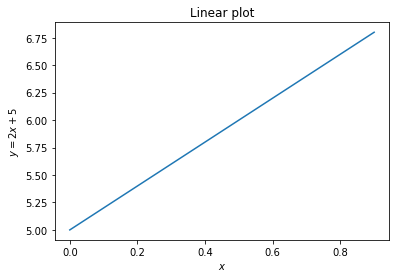

```python
import matplotlib.pyplot as plt

x = np.arange(0, 1, 0.1)
y = x*2 + 5
plt.plot(x, y)
plt.xlabel('$x$')
plt.ylabel('$y = 2x + 5$')
plt.title('Linear plot')
plt.show()
```

# Plotting a Sine Curve

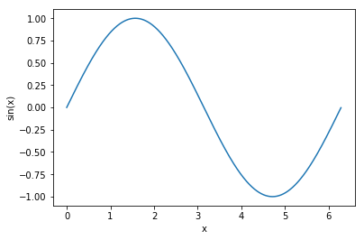

```python
from numpy import pi, sin

x = np.arange(0, 2*pi, 0.01)
y = sin(x)
plt.plot(x, y)
plt.xlabel('x')
plt.ylabel('sin(x)')
plt.show()
```

# Multi-Dimensional Data

- Numpy arrays can hold multi-dimensional data.
- To create a multi-dimensional array, we can pass a list of lists to the `array()` function:

```python
import numpy as np

x = np.array([[1,2], [3,4]])
x
```

```
array([[1, 2],
       [3, 4]])
```

# Arrays Containing Arrays

- A multi-dimensional array is an array of an arrays.
- The outer array holds the rows.
- Each row is itself an array:

```python
x[0]
```

```
array([1, 2])
```

```python
x[1]
```

```
array([3, 4])
```

- So the element in the second row, and first column is:

```python
x[1][0]
```

```
3
```

# Matrices

- We can create a matrix from a multi-dimensional array.

```python
M = np.matrix(x)
M
```

```
matrix([[1, 2],
        [3, 4]])
```

# Plotting Multi-Dimensional Data with Matrices

- If we supply a matrix to `plot()` then it will plot the y-values taken from the *columns* of the matrix (notice the transpose in the example below).

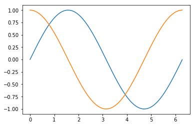

```python
from numpy import pi, sin, cos

x = np.arange(0, 2*pi, 0.01)
ax = plt.plot(x, np.matrix([sin(x), cos(x)]).T)
plt.show()
```

# Performance

- When we use `numpy` matrices in Python the corresponding functions are linked with libraries written in C and FORTRAN.
- For example, see the [BLAS (Basic Linear Algebra Subprograms) library](http://www.netlib.org/blas/).
- These libraries are very fast, and can be configured so that operations are performed in parallel on multiple CPU cores, or GPU hardware.

# Matrix Operators

- Once we have a matrix, we can perform matrix computations.
- To compute the [transpose](http://mathworld.wolfram.com/MatrixTranspose.html) and [inverse](http://mathworld.wolfram.com/MatrixInverse.html) use the `T` and `I` attributes:

To compute the transpose $M^{T}$

```python
M.T
```

```
matrix([[1, 3],
        [2, 4]])
```

To compute the inverse $M^{-1}$

```python
M.I
```

```
matrix([[-2. ,  1. ],
        [ 1.5, -0.5]])
```

# Matrix Dimensions

- The total number of elements, and the dimensions of the array:

```python
M.size
```

```
4
```

```python
M.shape
```

```
(2, 2)
```

```python
len(M.shape)
```

```
2
```

# Creating Matrices from Strings

- We can also create arrays directly from strings, which saves some typing:

```python
I2 = np.matrix('2 0; 0 2')
I2
```

```
matrix([[2, 0],
        [0, 2]])
```

- The semicolon starts a new row.

# Matrix Multiplication

Now that we have two matrices, we can perform [matrix multiplication](https://en.wikipedia.org/wiki/Matrix_multiplication):

```python
M * I2
```

```
matrix([[2, 4],
        [6, 8]])
```

# Matrix Indexing

- We can [index and slice matrices](http://docs.scipy.org/doc/numpy/user/basics.indexing.html) using the same syntax as lists.

```python
M[:,1]
```

```
matrix([[2],
        [4]])
```

# Slices are References

- If we use this is an assignment, we create a *reference* to the sliced elements, *not* a copy.

```python
V = M[:,1]  # This does not make a copy of the elements!
V
```

```
matrix([[2],
        [4]])
```

```python
M[0,1] = -2
V
```

```
matrix([[-2],
        [ 4]])
```

# Copying Matrices and Vectors

- To copy a matrix, or a slice of its elements, use the function `np.copy()`:

```python
M = np.matrix('1 2; 3 4')
V = np.copy(M[:,1])  # This does copy the elements.
V
```

```
array([[2],
       [4]])
```

```python
M[0,1] = -2
V
```

```
array([[2],
       [4]])
```

# Sums

One way we *could* sum a vector or matrix is to use a `for` loop.

```python
vector = np.arange(0.0, 100.0, 10.0)
vector
```

```
array([ 0., 10., 20., 30., 40., 50., 60., 70., 80., 90.])
```

```python
result = 0.0
for x in vector:
    result = result + x
result
```

```
450.0
```

- This is not the most *efficient* way to compute a sum.

# Efficient Sums

- Instead of using a `for` loop, we can use a numpy function `sum()`.
- This function is written in the C language, and is very fast.

```python
vector = np.array([0, 1, 2, 3, 4])
print(np.sum(vector))
```

```
10
```

# Summing Rows and Columns

- When dealing with multi-dimensional data, the 'sum()' function has a named argument `axis` which allows us to specify whether to sum along, each rows or columns.

```python
matrix = np.matrix('1 2 3; 4 5 6; 7 8 9')
print(matrix)
```

```
[[1 2 3]
 [4 5 6]
 [7 8 9]]
```

- To sum along rows:

```python
np.sum(matrix, axis=0)
```

```
matrix([[12, 15, 18]])
```

- To sum along columns:

```python
np.sum(matrix, axis=1)
```

```
matrix([[ 6],
        [15],
        [24]])
```

# Cumulative Sums

- Suppose we have a vector $\mathbf{x}$ of some length $n$, and want to compute a vector $(y_1, \ldots, y_n)$, where $y_i = \sum_{j=1}^{n} x_j$.

```python
import numpy as np
x = np.array([0, 1, 2, 3, 4])
y = np.cumsum(x)
print(y)
```

```
[ 0  1  3  6 10]
```

# Cumulative Sums along Rows and Columns

```python
x = np.matrix('1 2 3; 4 5 6; 7 8 9')
print(x)
```

```
[[1 2 3]
 [4 5 6]
 [7 8 9]]
```

```python
y = np.cumsum(x)
print(y)
np.cumsum(x, axis=0)
```

```
[[ 1  3  6 10 15 21 28 36 45]]
```

```
matrix([[ 1,  2,  3],
        [ 5,  7,  9],
        [12, 15, 18]], dtype=int32)
```

```python
np.cumsum(x, axis=1)
```

```
matrix([[ 1,  3,  6],
        [ 4,  9, 15],
        [ 7, 15, 24]])
```

# Cumulative Products

- Similarly we can compute $y_i = \Pi_{j=1}^{n} x_j$ using `cumprod()`:

```python
import numpy as np
x = np.array([1, 2, 3, 4, 5])
np.cumprod(x)
```

```
array([  1,   2,   6,  24, 120])
```

- We can compute cumulative products along rows and columns using the `axis` parameter, just as with the `cumsum()` example.

# Generating (Pseudo-)Random Numbers

- The nested module `numpy.random` contains functions for generating random numbers from different probability distributions.

```python
from numpy.random import normal, uniform, exponential, randint
```

- Suppose that we have a random variable $\epsilon \sim N(0, 1)$.
- In Python we can draw from this distribution like so:

```python
epsilon = normal()
epsilon
```

```
0.1465312427787133
```

- If we execute another call to the function, we will make a *new* draw from the distribution:

```python
epsilon = normal()
epsilon
```

```
-2.3135050810408773
```

# Pseudo-Random Numbers

- Strictly speaking, these are not random numbers.
- They rely on an initial state value called the *seed*.
- If we know the seed, then we can predict with total accuracy the rest of the sequence, given any "random" number.
- Nevertheless, statistically they behave like independently and identically-distributed values.
  - Statistical tests for correlation and auto-correlation give insignificant results.
- For this reason they called *pseudo*-random numbers.
- The algorithms for generating them are called Pseudo-Random Number Generators (PRNGs).
- Some applications, such as cryptography, require genuinely unpredictable sequences.
  - never use a standard PRNG for these applications!

# Managing Seed Values

- In some applications we need to reliably reproduce the same sequence of pseudo-random numbers that were used.
- We can specify the seed value at the beginning of execution to achieve this.
- Use the function `seed()` in the `numpy.random` module.

# Setting the Seed

```python
from numpy.random import seed

seed(5)
```

```python
normal()
```

```
0.44122748688504143
```

```python
normal()
```

```
-0.33087015189408764
```

```python
seed(5)
```

```python
normal()
```

```
0.44122748688504143
```

```python
normal()
```

```
-0.33087015189408764
```

# Drawing Multiple Samples

- To generate more than number, we can specify the `size` parameter:

```python
normal(size=10)
```

[output not shown]

- If you are generating very many variates, this will be *much* faster than using a for loop
- We can also specify more than one dimension:

```python
normal(size=(5,5))
```

```
array([[-0.35882895,  0.6034716 , -1.66478853, -0.70017904,  1.15139101],
       [ 1.85733101, -1.51117956,  0.64484751, -0.98060789, -0.85685315],
       [-0.87187918, -0.42250793,  0.99643983,  0.71242127,  0.05914424],
       [-0.36331088,  0.00328884, -0.10593044,  0.79305332, -0.63157163],
       [-0.00619491, -0.10106761, -0.05230815,  0.24921766,  0.19766009]])
```

# Histograms

- We can plot a histogram of randomly distributed data using the `hist()` function from matplotlib:

[figure not shown]

```python
import matplotlib.pyplot as plt

data = normal(size=10000)
ax = plt.hist(data)
plt.title('Histogram of normally distributed data ($n=10^5$)')
plt.show()
```

# Computing Histograms as Matrices

- The function `histogram()` in the `numpy` module will count frequencies into bins and return the result as a 2-dimensional array.

```python
import numpy as np
np.histogram(data)
```

[output not shown]

# Summary Statistics

- We can compute the summary statistics of a sample of values using the numpy functions `mean()` and `var()` to compute the sample mean $\bar{X}$ and sample [variance](https://en.wikipedia.org/wiki/Variance) $\sigma_{X}^2$ .

```python
np.mean(data)
```

```
-0.00045461080333497925
```

```python
np.var(data)
```

```
1.0016048722546331
```

- These functions also have an `axis` parameter to compute means and variances of columns or rows of a multi-dimensional data-set.

# Summary Statistics with `nan` Values

- If the data contains `nan` values, then the summary statistics will also be `nan`.

```python
from numpy import nan
import numpy as np
data = np.array([1, 2, 3, 4, nan])
np.mean(data)
```

```
nan
```

- To omit `nan` values from the calculation, use the functions `nanmean()` and `nanvar()`:

```python
np.nanmean(data)
```

```
2.5
```

# Discrete Random Numbers

- The `randint()` function in `numpy.random` can be used to draw from a uniform discrete probability distribution.
- It takes two parameters: the low value (inclusive), and the high value (exclusive).
- So to simulate one roll of a die, we would use the following Python code.

```python
die_roll = randint(0, 6) + 1
die_roll
```

```
4
```

- Just as with the `normal()` function, we can generate an entire sequence of values.
- To simulate a [Bernoulli process](https://en.wikipedia.org/wiki/Bernoulli_process) with $n=20$ trials:

```python
bernoulli_trials = randint(0, 2, size = 20)
bernoulli_trials
```

```
array([1, 1, 0, 1, 1, 1, 0, 1, 0, 0, 1, 1, 1, 0, 0, 0, 0, 1, 1, 0])
```